# Shah_business

Shah Ali

2/10/2022

## Executive summary:

In this project I am tasked to help a company which is operating small and mid-size apartments hosting 2-6 guests to set the on optimum rental price for its apartments in the city of **Puglia** in Italy. To achieve this I will build a price prediction model based on data provided by [Inside Airbnb](http://insideairbnb.com/get-the-data.html) which was scraped between December 30, 2021 and December 31, 2021. The prediction was built on several features of the accommodation such as the number of bedrooms, bathrooms, the number of guests it accommodates as well as on information about the host, including the scores of ratings given to apartment. Moreover, on several variables aimed at describing different kinds of amenities offered by the apartment already in the city. I analyzed 4 different kinds of models, to find the best prediction, namely OLS, CART, Random forest and GBM. Out of these the I chose the prediction results of random forest model to be the best one. To see all the codes and files I created for this project please visit my [Github](https://github.com/shahaligardezi/DA3/tree/main/Assignment2)

## Data Cleaning

The data for the chosen destination was a large dataset with more than 33000 observations and 74 variables. This data required intense cleaning before I could begin our analysis. I performed basic cleaning that involved filtering the property type to the ones of our interest that are apartments so I selected all observation of Entire apt, Entire serviced apartments, Entire Loft and Entire Condominium, and then I filtered the number of guests to 2 to 6. The main part of the cleaning process rested on cleaning the amenities. In our dataset all the amenities were written together in one large vector with total of 1442 unique amenities. Since I am interested in analyzing the effect of each amenity on the target variable I needed to create meaningful dummy variable out of the names of amenities. I separated each amenity from the list, grouped them together if they were similar (Wifi & Internet, TV and cable) and chose only those which had at least 1% of measurable observations. In this way I was able to narrow down the amenities to 85.

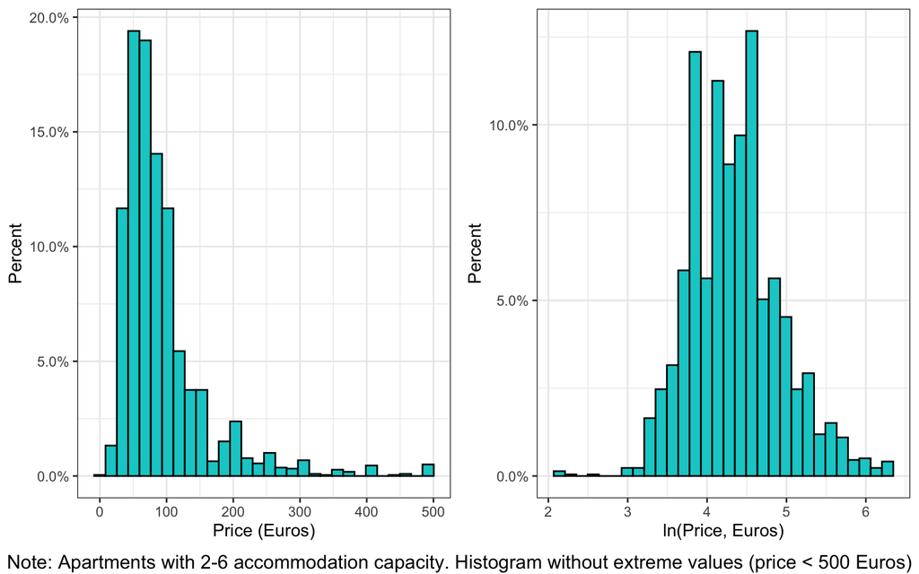

In order to deal with the missing values, I initially dropped those variables that had more than 50% of the missing values and using domain knowledge, I dropped those variables as well which will play no role in our analysis for example picture, url, name, host response rate etc. For the rest I applied imputation. Some of the main variables like number of bathrooms, bedrooms and beds had less than 1% of missing values, for these variables I used logical assumptions while imputing values. For instance, for bathrooms I imputed the median value in place of missing values. For bedrooms I assumed 2 people can share one room thus I imputed the value of reminder of the division by 2. For number of beds I assumed that for 3 people atleast 2 beds are needed. I didn’t not create a flag variable as the number of missing values are less, however for variables with more than 30% missing values I created a flag variable with a value of 1 and imputed median value. In this way our dataset was left with no missing values.

During the cleaning of the target variable, price, I dropped all the observations where price was not available as we should impute in our target variable. Since the analysis focused on small to medium size of apartments, I dropped the price above 500 Euros which were less than less than 1% of observations considering them as extreme values. Then the distribution of the price was checked which was found to be bit right skewed due to the presence of high values such as 500 Euros. I decided to proceed with price variable without the log transformation for this analysis. While it is true that that log will bring us closer to normal distribution of the variable, but it will also lead to errors when transformed back to normal prices.

## Variables and feature engineering

After data cleaning the variables we are left with are broadly divided as the following.

*Numeric variables:* These variables define size for example, number of beds, number of accommodates, number of bathrooms and bedrooms, the minimum number of nights required to rent the place and the availability of the apartment in 365 days of the year. *Factor variables:* These are categorical variables that are either in string or numeric form. For example, the neighborhood the apartment is in or the type of property (apartment, condominium or loft). *Dummy variables:* These are binary variables mostly describing the amenities offered in the property such the Wifi, pool, beachfront facing property, kitchen supplies, elevator etc. *Review variables:* These describe the reviews and ratings characteristics for an individual property. Number of reviews, the rating for those reviews and the mean monthly reviews received. *Host variables:* These variables describe the characteristics of the host of the property. They are binary variables like host is a super-host or if the host is verified

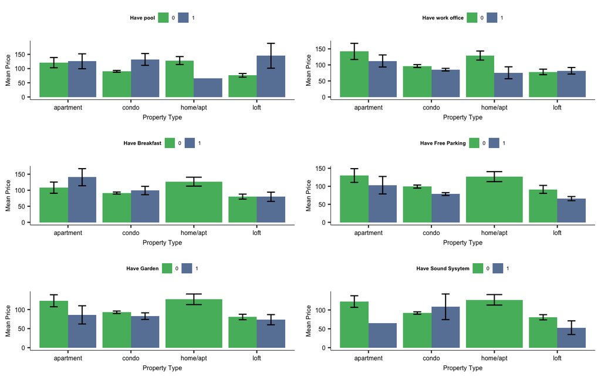

After the variables are set, we need to find the interaction terms between property type and amenities to include in our prediction models. In order to evaluate which interactions terms to use, I logically selected those amenities for our analysis which have an effect on the price. I used the helper functions provided by Bekes & Kézdi to help me plot the histogram which help me with the logical selection. The amenities whose inclusion showed more than 10 Euros of difference on price were included in our model. In this way I was left with 40 important amenities.

## Cross validation & Holdout

To improve model performance, I created work set (train and test) sample and the holdout set from the dataset. The value of k was set at 5 which ensured 80% of the 2100 observations for training and 20% for test. The models that I will build later are each trained through 5-fold cross-validation so as to render the least overfitting coefficients, taking the average of each model’s 5 test folds, warranting the RMSE and BIC statistics with no assumptions.

## OLS Predictive Model

**Versions of the Airbnb Apartment Price Prediction Models**

| Model | Predictor Variables |
| --- | --- |
| M1 | ~ n_accommodates |
| M2 | ~ n_accommodates+ basic_lev |
| M3 | ~ n_accommodates+ basic_lev + basic_add + reviews + host + dummies |
| M4 | ~ n_accommodates+ basic_lev + basic_add + reviews + host + dummies + interaction |

Comparing Model Fit Model Measures

| Model | Coefficients | R_squared | BIC | Training_RMSE | Test_RMSE |
| --- | --- | --- | --- | --- | --- |
| M1 | 2 | 0.031 | 19665 | 66.8 | 66.7 |
| M2 | 8 | 0.084 | 19612 | 65.0 | 65.1 |
| M3 | 71 | 0.227 | 19785 | 59.7 | 63.0 |
| M4 | 194 | 0.294 | 20545 | 57.0 | 70.8 |
| LASSO | 92 | 0.142 | NA | NA | 62.9 |

## Random Forest

Random Forest is the machine learning predictive algorithm that uses the results of many regression trees. The algorithm creates large number of trees and averages the prediction of them to achieve one average. In this way better prediction is created as opposed to a single model. In our case we used the same holdout and work set and run our model with tuning parameter to allow cross validation to find the tuning parameter value with lowest RMSE value.

Random Forest RMSE by tuning parameters

| nodes | 8 | 10 | 12 |
| --- | --- | --- | --- |
| 5 | 58.2 | 57.8 | 57.7 |
| 10 | 58.9 | 58.7 | 58.5 |
| 15 | 59.4 | 59.2 | 59.0 |

## Variable Importance

Variable importance is a helpful diagnostic tool that helps us gain useful insight about how much each variable contributes towards predicting our target variable. The results of variable importance, from both self-tuned and auto-tuned Random Forest were mostly same. The following top 10 important variable plot shows variables which ones had the largest MSE reduction in auto tuned model. It shows that number of days of availability is the most important x predictor with more than 6% importance. In second chart these variables are grouped based on their factor groups, it turns out that amenities account for more than 50% of importance.

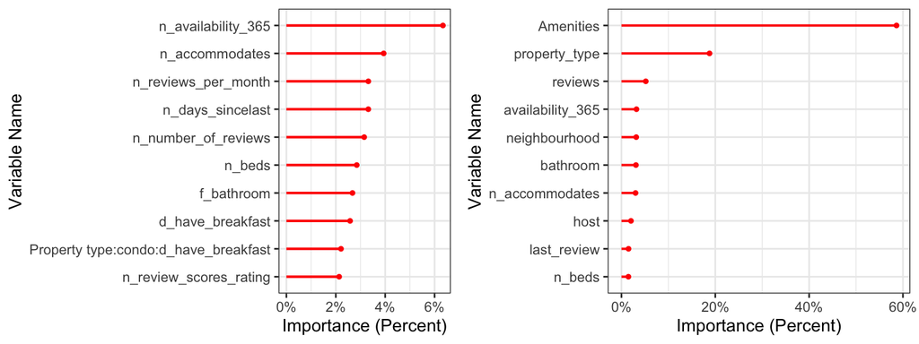

## Partial Dependence Plot (PDP)

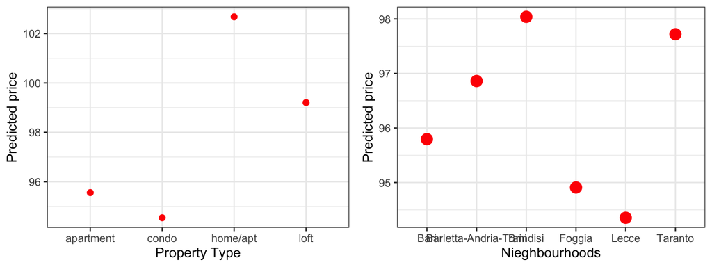

## Sub sample

Performance across sub-sample

| Var.1 | RMSE | Mean.price | RMSE.price |
| --- | --- | --- | --- |
| Apartment size | NA | NA | NA |
| large apt | 54.6 | 92.5 | 0.591 |
| small apt | 52.6 | 88.3 | 0.596 |
| Beds | NA | NA | NA |
| 2 | 53.6 | 94.0 | 0.571 |
| 3 | 46.5 | 85.8 | 0.542 |
| 4 | 59.4 | 81.9 | 0.726 |
| 5 | 43.4 | 91.8 | 0.473 |
| 6 | 89.9 | 145.6 | 0.618 |
| Property Type | NA | NA | NA |
| apartment | 65.9 | 121.3 | 0.543 |
| condo | 55.6 | 90.7 | 0.613 |
| loft | 41.1 | 82.5 | 0.499 |

## Conclusion

Horse Race of Models CV RSME

|  | CV RMSE |
| --- | --- |
| OLS | 63.0 |
| CART | 66.7 |
| Random forest 1: Tuning provided | 57.7 |
| Random forest 2: Auto Tuning | 57.4 |
| GBM | 59.7 |

Credits: Codes by Bekes and Kézdi the author of DATA ANALYSIS FOR BUSINESS, ECONOMICS, AND POLICY. [CAMBRIDGE UNIV PRESS. served to be extremely for this analysis. They provided the inspiration for starting and completing the project.